# Innovation Systems For Sustainability

Jonas Kreutzer  
[@pjkreutzer](https://bento.me/pjkreutzer)

2024-06-12

# The Game

## Rule Reminder

1. Set innovation goals 🎯
2. Innovators draw cards 💸
3. Innovators may play cards 🛠️
4. Consume (while 2 and 3 happen) 🛍️
5. Discuss outcomes and state of game 💬
6. Negotiate innovation goals. Fight to make your role happy with how it is going! 📣

## Round 1

## Round 2

## Round 3

## Round 4

## Round 5 — Election 🗳️

## Round 6

## Round 7

## Round 8

## Round 9

## Round 10 — 🏁 Last Round!

## Reflection

What surprised you in the way the game unfolded? Were there critical moments in which the game could have developed differently?

What would have been needed to have a different game?

## Innovation Iceberg Heuristic

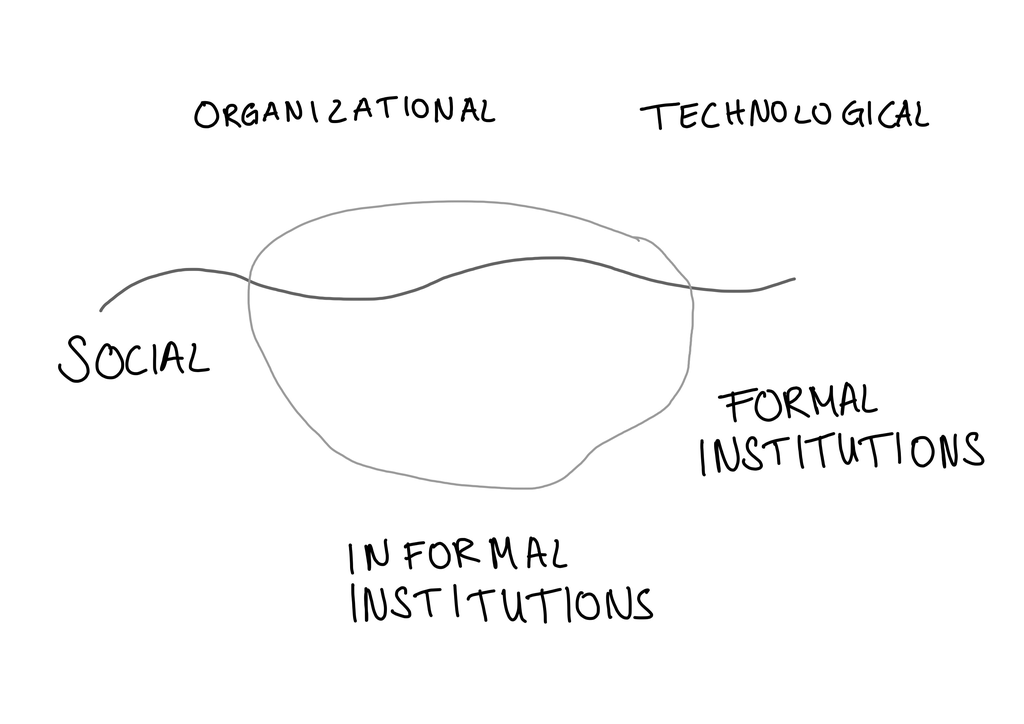

# Innovation Systems – A Brief Introduction

## Innovation System Functions

1. Entrepreneurial Activities
2. Knowledge Development
3. Knowledge Diffusion Through Networks
4. Guidance of the Search
5. Market Formation
6. Resources Mobilisation
7. Creation of Legitimacy

Hekkert et al. (2007)

## Motors of Change

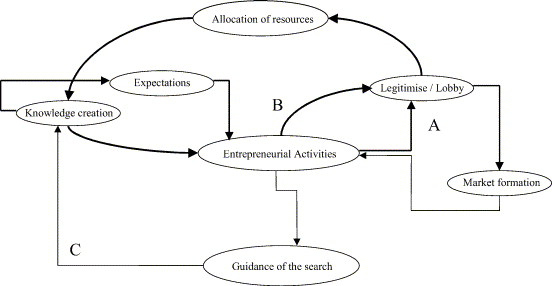

Hekkert et al. (2007) 426

## Navigate Innovation Systems as an Entrepreneur

Which of these functions do you participate in?

1. Entrepreneurial Activities
2. Knowledge Development
3. Knowledge Diffusion Through Networks
4. Guidance of the Search
5. Market Formation
6. Resources Mobilisation
7. Creation of Legitimacy

Take a systems perspective to create new ideas, engage with stakeholders, shape operations or strategy.

Hekkert et al. (2007)

## Leverage Points to Intervene in Systems

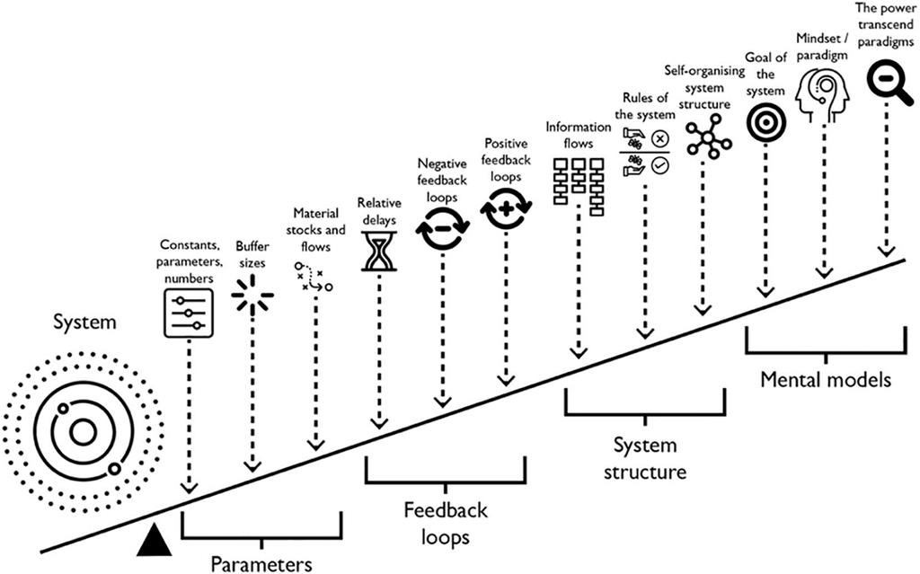

“Leverage Points—Places to Intervene in a System” (2009)

Image credit: [Monash University](https://www.behaviourworksaustralia.org/blog/how-systems-thinking-compliments-behavioural-approaches-in-solving-complex-problems)

### Example: Oatly marketing working towards paradigm shift

1. Knowledge Diffusion
2. Creating Legitimacy

Repeatedly pointing out flaws in existing food (dairy) paradigm.

[figure not shown]

## Reflection

What role do you (personally) have at as a sustainability entrepeneur? Was it different from your role in the game? How did you view the role that you usually have in the game?

What aspects of the game did you recognize from reality?

# Innovation is a systemic event. Applying systemic tools can help identify new solutions to stubborn problems.

## Game Resources

https://pjkreutzer.github.io/innovation-systems-game/

## Feedback

https://forms.office.com/e/9yesS7saGb

## References

Hekkert, M. P., Suurs, R. A. A., Negro, S. O., Kuhlmann, S., & Smits, R. E. H. M. (2007). Functions of innovation systems: A new approach for analysing technological change. *Technological Forecasting and Social Change*, *74*(4), 413–432. https://doi.org/10.1016/j.techfore.2006.03.002

Leverage Points—Places to Intervene in a System. (2009). In D. H. Meadows, *Thinking in systems: A primer* (pp. 145–165). Earthscan.